# Raport Proiect Statistica cu R-lang

2022-02-03

# Prerequisites

Setam environment pentru R markdown

```r
knitr::opts_chunk$set(fig.width = 10, fig.height = 10)
```

Initializam figurile/ploturile sa fie 1000x1000 ca dimensiune.

# Header

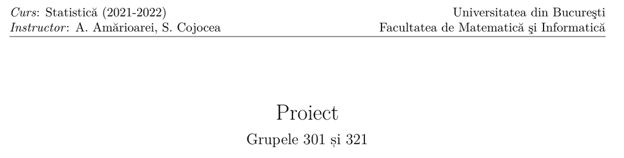

# Nota

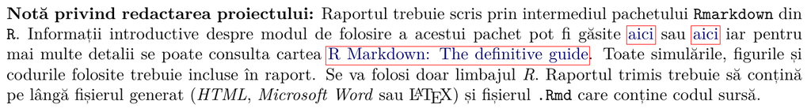

acest proiect contine fisierul `raport.Rmd` plus `raport.html` si `raport.docx` care sunt fisierele generate cu RMarkdown compiler.

# Problema 1

### nota problema 1

Pentru problema 1 am creat o colectie de functii utile care pot fi reutilizate. Principul din spate se numeste `functional programming`.

Functie pentru extragerea de cei 2 minimi si maximul dintre valorile `(a, b, c)`.

```r
get_min_max_2nd_min <- function(a, b, c) {
    # punem valorile intr-un array
    values <- c(a, b, c)
    # luam minim
    minimum <- min(values)
    # luam maxim
    maximum <- max(values)
    # alfam al doilea min
    # '! values %in% c(minimum)' inseamna toate valorile care nu sunt in vectorul c(minimum)
    # adica doar vectorul cu valoarea minima
    second_min <- min(values[! values %in% c(minimum)])
    # returnam un vector to toate valorile in ordine crescatoare
    # bune pentru formula de triunghi obtuz
    return (c(minimum, second_min, maximum))
}
```

Functie pentru verificarea conditiei de `triunghi obtuz` din setul de 3 lungimi `(a, b, c)`.

```r
is_obtuse_triangle <- function(a, b, c) {
    # formula este
    # min^2 + second_min^2 < max^2 -> if TRUE then obtuz else 'nu e obtuz'

    # luam valorile si le ridicam la patrat pentru formula
    values <- get_min_max_2nd_min(a, b, c) ^ 2
    # membrul stang al egalitatii
    min_sum <- values[1] + values[2]

    # daca suma minimelor < max^2
    if (min_sum < values[3]) {
        # obtuz
        return (TRUE)
    }
    # not obtuz
    return (FALSE)
}
```

Functie pentru verificarea conditiei de `triunghi` din setul de 3 lungimi `(a, b, c)`.

```r
is_triangle <- function(a, b, c) {
    # daca toate laturile sunt mai mici decat 1 pe 2 (0.5)
    if (a <= 0.5 && b <= 0.5 && c <= 0.5) {
        # triunghi
        return (TRUE)
    }
    # non-triunghi
    return (FALSE)
}
```

## Cerinta

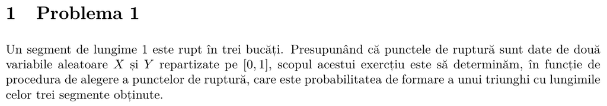

Pentru inceput setam variable esentiale pentru intreaga executie a problemei numarul 1.

```r
total <- 5000 # nr total de simulari
swap <- TRUE # pentru inversarea lui X si Y atunci cand X > Y
```

## Procedura 1

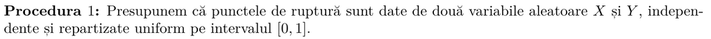